# Data Visualization and Descriptive Statistics in R

Hands-on Training Using the Diarrhea Dataset

Prof. Dr. Bijay Lal Pradhan

5 October 2026

# 1 Introduction

This training module develops practical skills in **data inspection, data cleaning, descriptive statistics, exploratory data analysis (EDA), and data visualization in R**.

The examples use the diarrhea dataset available from:

`https://raw.githubusercontent.com/bijayprad/data/refs/heads/main/dirrhea.csv`

> **Dataset note:** The training examples use the variables exactly as represented in the source CSV. Always verify definitions, coding, and units against the original data documentation before using the dataset for substantive research.

The purpose is not only to produce graphs and numerical summaries. Trainees should learn to:

1. understand the structure and meaning of variables;
2. identify missing, inconsistent, and unusual values;
3. choose an appropriate statistical summary;
4. choose an appropriate graph;
5. compare groups carefully;
6. describe relationships without overstating them;
7. communicate results in a research-oriented way.

# 2 Learning Objectives

By the end of this module, trainee should be able to:

- import a CSV file directly from a URL;
- inspect the dimensions and structure of a dataset;
- identify numerical and categorical variables;
- detect missing and inconsistent values;
- convert variables to appropriate R classes;
- calculate measures of central tendency and dispersion;
- create frequency and contingency tables;
- produce publication-ready exploratory graphs with `ggplot2`;
- compare numerical variables across groups;
- visualize relationships between numerical variables;
- calculate and interpret correlation appropriately;
- identify potential outliers;
- distinguish an unusual observation from a data-entry error;
- write concise research-style interpretations.

# 3 Packages and Setup

Install packages once if necessary:

```r
install.packages(c(
  "tidyverse",
  "janitor",
  "skimr",
  "scales",
  "patchwork"
))
```

Load the packages:

```r
library(tidyverse)
library(janitor)
library(skimr)
library(scales)
library(patchwork)

theme_set(theme_classic())
```

### 3.0.1 Importing the Diarrhea Dataset

## 3.1 Read the CSV directly from GitHub

```r
url <- "https://raw.githubusercontent.com/bijayprad/data/refs/heads/main/dirrhea.csv"

dirdata <- read_csv(
  url,
  na = c("", "NA")
)
dirdata
```

| ID | Department | Sex | Age | Fever | DiaMaxNo_24hrs | DiaDurInDays | DegreeDehy | OutComeDisc |
| --- | --- | --- | --- | --- | --- | --- | --- | --- |
| 1 | OPD | 1 | 6 | No | 7 | 2 | some | NA |
| 2 | OPD | 2 | 8 | No | 5 | 1 | some | NA |
| 3 | IPD | 1 | 12 | No | 10 | 3 | some | Improved |
| 4 | IPD | 1 | 2 | Yes | 9 | 1 | some | Improved |
| 5 | IPD | 1 | 12 | Yes | 8 | 2 | some | Improved |
| 6 | OPD | 2 | 12 | No | 7 | 5 | some | NA |
| 7 | IPD | 2 | 10 | No | 12 | 2 | some | Improved |
| 8 | IPD | 1 | 21 | No | 8 | 2 | some | Improved |
| 9 | IPD | 2 | 6 | No | 8 | 2 | some | Improved |
| 10 | IPD | 1 | 37 | No | 10 | 2 | some | Improved |

[output cut: 1286 more lines]

## 3.2 First inspection

```r
head(dirdata)
```

| ID | Department | Sex | Age | Fever | DiaMaxNo_24hrs | DiaDurInDays | DegreeDehy | OutComeDisc |
| --- | --- | --- | --- | --- | --- | --- | --- | --- |
| 1 | OPD | 1 | 6 | No | 7 | 2 | some | NA |
| 2 | OPD | 2 | 8 | No | 5 | 1 | some | NA |
| 3 | IPD | 1 | 12 | No | 10 | 3 | some | Improved |
| 4 | IPD | 1 | 2 | Yes | 9 | 1 | some | Improved |
| 5 | IPD | 1 | 12 | Yes | 8 | 2 | some | Improved |
| 6 | OPD | 2 | 12 | No | 7 | 5 | some | NA |

```r
tail(dirdata)
```

| ID | Department | Sex | Age | Fever | DiaMaxNo_24hrs | DiaDurInDays | DegreeDehy | OutComeDisc |
| --- | --- | --- | --- | --- | --- | --- | --- | --- |
| 1291 | IPD | 2 | 3 | Yes | 10 | 9 | Some | Improved |
| 1292 | IPD | 1 | 2 | No | 3 | 7 | Some | Improved |
| 1293 | IPD | 2 | 11 | Yes | 5 | 3 | Some | Improved |
| 1294 | IPD | 2 | 6 | No | 3 | 3 | Some | Improved |
| 1295 | IPD | 2 | 2 | No | 10 | 2 | Severe | Improved |
| 1296 | IPD | 2 | 6 | No | 5 | 3 | some | Improved |

```r
dim(dirdata)
```

```
## [1] 1296    9
```

```r
names(dirdata)
```

```
## [1] "ID"             "Department"     "Sex"            "Age"
## [5] "Fever"          "DiaMaxNo_24hrs" "DiaDurInDays"   "DegreeDehy"
## [9] "OutComeDisc"
```

The current CSV contains the following variables:

| Variable | Description for training | Suggested type |
| --- | --- | --- |
| `ID` | Record identifier | Integer |
| `Department` | Department/category such as OPD or IPD | Factor |
| `Sex` | Sex coded as 1/2 in the source | Factor |
| `Age` | Age value recorded in the source | Numeric |
| `Fever` | Fever status | Factor |
| `DiaMaxNo_24hrs` | Maximum number of diarrhea episodes in 24 hours | Integer |
| `DiaDurInDays` | Duration of diarrhea | Numeric |
| `DegreeDehy` | Degree of dehydration | Factor |
| `OutComeDisc` | Recorded outcome/disposition | Factor |

> **Data documentation note:** The CSV records `Age` as a numerical variable and `Sex` as codes 1 and 2. The unit of `Age` is not encoded in the CSV itself, so the original data documentation should be checked before describing it as months, years, or another unit.

# 4 Data Audit Before Analysis

A good statistical analysis starts with an audit. Do not immediately make graphs from an unfamiliar dataset.

## 4.1 Structure

```r
str(dirdata)
```

```
## spc_tbl_ [1,296 × 9] (S3: spec_tbl_df/tbl_df/tbl/data.frame)
##  $ ID            : num [1:1296] 1 2 3 4 5 6 7 8 9 10 ...
##  $ Department    : chr [1:1296] "OPD" "OPD" "IPD" "IPD" ...
##  $ Sex           : num [1:1296] 1 2 1 1 1 2 2 1 2 1 ...
##  $ Age           : num [1:1296] 6 8 12 2 12 12 10 21 6 37 ...
##  $ Fever         : chr [1:1296] "No" "No" "No" "Yes" ...
##  $ DiaMaxNo_24hrs: num [1:1296] 7 5 10 9 8 7 12 8 8 10 ...
##  $ DiaDurInDays  : num [1:1296] 2 1 3 1 2 5 2 2 2 2 ...
##  $ DegreeDehy    : chr [1:1296] "some" "some" "some" "some" ...
##  $ OutComeDisc   : chr [1:1296] NA NA "Improved" "Improved" ...
##  - attr(*, "spec")=
##   .. cols(
##   ..   ID = col_double(),
##   ..   Department = col_character(),
##   ..   Sex = col_double(),
##   ..   Age = col_double(),
##   ..   Fever = col_character(),
##   ..   DiaMaxNo_24hrs = col_double(),
##   ..   DiaDurInDays = col_double(),
##   ..   DegreeDehy = col_character(),
##   ..   OutComeDisc = col_character()
##   .. )
##  - attr(*, "problems")=<pointer: 0x000001db41464fb0>
```

```r
glimpse(dirdata)
```

```
## Rows: 1,296
## Columns: 9
## $ ID             <dbl> 1, 2, 3, 4, 5, 6, 7, 8, 9, 10, 11, 12, 13, 14, 15, 16, …
## $ Department     <chr> "OPD", "OPD", "IPD", "IPD", "IPD", "OPD", "IPD", "IPD",…
## $ Sex            <dbl> 1, 2, 1, 1, 1, 2, 2, 1, 2, 1, 2, 2, 2, 1, 1, 2, 1, 1, 1…
## $ Age            <dbl> 6, 8, 12, 2, 12, 12, 10, 21, 6, 37, 12, 3, 23, 7, 6, 4,…
## $ Fever          <chr> "No", "No", "No", "Yes", "Yes", "No", "No", "No", "No",…
## $ DiaMaxNo_24hrs <dbl> 7, 5, 10, 9, 8, 7, 12, 8, 8, 10, 7, 9, 3, 11, 10, 6, 12…
## $ DiaDurInDays   <dbl> 2, 1, 3, 1, 2, 5, 2, 2, 2, 2, 2, 2, 2, 2, 1, 1, 3, 2, 2…
## $ DegreeDehy     <chr> "some", "some", "some", "some", "some", "some", "some",…
## $ OutComeDisc    <chr> NA, NA, "Improved", "Improved", "Improved", NA, "Improv…
```

## 4.2 Number of observations and variables

```r
nrow(dirdata)
```

```
## [1] 1296
```

```r
ncol(dirdata)
```

```
## [1] 9
```

## 4.3 Summary

```r
summary(dirdata)
```

```
##        ID             Department        Sex             Age
##  Min.   :   1.0   Length   :1296   Min.   :1.000   Min.   : 1.0
##  1st Qu.: 324.8   N.unique :   2   1st Qu.:1.000   1st Qu.: 5.0
##  Median : 648.5   N.blank  :   0   Median :2.000   Median : 9.0
##  Mean   : 648.5   Min.nchar:   3   Mean   :1.667   Mean   :11.2
##  3rd Qu.: 972.2   Max.nchar:   3   3rd Qu.:2.000   3rd Qu.:12.0
##  Max.   :1296.0                    Max.   :2.000   Max.   :59.0
##
##        Fever      DiaMaxNo_24hrs    DiaDurInDays        DegreeDehy
##  Length   :1296   Min.   : 2.000   Min.   : 1.000   Length   :1296
##  N.unique :   2   1st Qu.: 7.000   1st Qu.: 1.000   N.unique :   4
##  N.blank  :   0   Median : 9.000   Median : 2.000   N.blank  :   0
##  Min.nchar:   2   Mean   : 9.836   Mean   : 2.316   Min.nchar:   4
##  Max.nchar:   3   3rd Qu.:12.000   3rd Qu.: 3.000   Max.nchar:   6
##  NAs      :   1   Max.   :35.000   Max.   :52.000
##                                    NAs    :2
##     OutComeDisc
##  Length   :1296
##  N.unique :   1
##  N.blank  :   0
##  Min.nchar:   8
##  Max.nchar:   8
##  NAs      : 196
##
```

## 4.4 Variable classes

```r
sapply(dirdata, class)
```

```
##             ID     Department            Sex            Age          Fever
##      "numeric"    "character"      "numeric"      "numeric"    "character"
## DiaMaxNo_24hrs   DiaDurInDays     DegreeDehy    OutComeDisc
##      "numeric"      "numeric"    "character"    "character"
```

## 4.5 Unique values of categorical variables

```r
lapply(dirdata[c("Department", "Sex", "Fever", "DegreeDehy", "OutComeDisc")], unique)
```

```
## $Department
## [1] "OPD" "IPD"
##
## $Sex
## [1] 1 2
##
## $Fever
## [1] "No"  "Yes" NA
##
## $DegreeDehy
## [1] "some"   "Severe" "severe" "Some"
##
## $OutComeDisc
## [1] NA         "Improved"
```

## 4.6 Missing values

```r
colSums(is.na(dirdata))
```

```
##             ID     Department            Sex            Age          Fever
##              0              0              0              0              1
## DiaMaxNo_24hrs   DiaDurInDays     DegreeDehy    OutComeDisc
##              0              2              0            196
```

# 5 Data Cleaning and Preparation

Cleaning should be **transparent and reproducible**. Do not delete observations simply because they look unusual.

## 5.1 Standardize text

The source contains inconsistent capitalization in `DegreeDehy`, such as `some` and `Some`, and `severe` and `Severe`. We can standardize these values without changing their meaning.

```r
dirdata <- dirdata %>%
  mutate(
    Department = factor(str_to_upper(str_trim(Department))),
    Sex = factor(Sex, levels = c(1, 2), labels = c("Male", "Female")),
    Fever = factor(str_to_title(str_trim(Fever))),
    DegreeDehy = factor(str_to_title(str_trim(DegreeDehy))),
    OutComeDisc = factor(str_trim(OutComeDisc)),
    ID = as.integer(ID)
  )

glimpse(dirdata)
```

```
## Rows: 1,296
## Columns: 9
## $ ID             <int> 1, 2, 3, 4, 5, 6, 7, 8, 9, 10, 11, 12, 13, 14, 15, 16, …
## $ Department     <fct> OPD, OPD, IPD, IPD, IPD, OPD, IPD, IPD, IPD, IPD, IPD, …
## $ Sex            <fct> Male, Female, Male, Male, Male, Female, Female, Male, F…
## $ Age            <dbl> 6, 8, 12, 2, 12, 12, 10, 21, 6, 37, 12, 3, 23, 7, 6, 4,…
## $ Fever          <fct> No, No, No, Yes, Yes, No, No, No, No, No, No, No, No, N…
## $ DiaMaxNo_24hrs <dbl> 7, 5, 10, 9, 8, 7, 12, 8, 8, 10, 7, 9, 3, 11, 10, 6, 12…
## $ DiaDurInDays   <dbl> 2, 1, 3, 1, 2, 5, 2, 2, 2, 2, 2, 2, 2, 2, 1, 1, 3, 2, 2…
## $ DegreeDehy     <fct> Some, Some, Some, Some, Some, Some, Some, Some, Some, S…
## $ OutComeDisc    <fct> NA, NA, Improved, Improved, Improved, NA, Improved, Imp…
```

## 5.2 Check duplicates

```r
sum(duplicated(dirdata))
```

```
## [1] 0
```

Check duplicated IDs:

```r
dirdata %>%
  count(ID) %>%
  filter(n > 1)
```

| ID | n |
| --- | --- |

> An observation that looks duplicated should be investigated against the original records. Never remove duplicates automatically.

## 5.3 Check numerical ranges

```r
dirdata %>%
  summarise(
    Age_min = min(Age, na.rm = TRUE),
    Age_max = max(Age, na.rm = TRUE),
    DiaMax_min = min(DiaMaxNo_24hrs, na.rm = TRUE),
    DiaMax_max = max(DiaMaxNo_24hrs, na.rm = TRUE),
    DiaDur_min = min(DiaDurInDays, na.rm = TRUE),
    DiaDur_max = max(DiaDurInDays, na.rm = TRUE)
  )
```

| Age_min | Age_max | DiaMax_min | DiaMax_max | DiaDur_min | DiaDur_max |
| --- | --- | --- | --- | --- | --- |
| 1 | 59 | 2 | 35 | 1 | 52 |

## 5.4 Investigate unusual values

For example:

```r
dirdata %>%
  filter(DiaDurInDays > quantile(DiaDurInDays, 0.99, na.rm = TRUE)) %>%
  arrange(desc(DiaDurInDays))
```

| ID | Department | Sex | Age | Fever | DiaMaxNo_24hrs | DiaDurInDays | DegreeDehy | OutComeDisc |
| --- | --- | --- | --- | --- | --- | --- | --- | --- |
| 1270 | IPD | Male | 10 | Yes | 10 | 52 | Some | Improved |
| 278 | IPD | Male | 48 | No | 8 | 22 | Some | Improved |
| 274 | IPD | Female | 9 | No | 15 | 13 | Severe | Improved |
| 1031 | OPD | Female | 31 | Yes | 23 | 12 | Severe | Improved |
| 702 | IPD | Male | 20 | No | 4 | 11 | Some | Improved |
| 1101 | IPD | Female | 6 | No | 13 | 10 | Severe | Improved |
| 1102 | IPD | Female | 18 | Yes | 10 | 10 | Some | Improved |
| 1170 | IPD | Female | 9 | Yes | 12 | 10 | Severe | Improved |
| 236 | IPD | Female | 9 | Yes | 7 | 9 | Some | Improved |
| 1189 | IPD | Male | 52 | No | 6 | 9 | Some | Improved |

[output cut: 2 more lines]

The purpose of this step is **investigation**, not automatic deletion.

# 6 Understanding Variable Types

## 6.1 Categorical variables

Examples in this dataset include:

- `Department`
- `Sex`
- `Fever`
- `DegreeDehy`
- `OutComeDisc`

## 6.2 Numerical variables

Examples include:

- `Age`
- `DiaMaxNo_24hrs`
- `DiaDurInDays`

`DiaMaxNo_24hrs` is a count and is therefore discrete in its measurement scale, while `Age` and `DiaDurInDays` are numerical measurements as recorded in the dataset.

## 6.3 Choosing a graph

| Question | Variable structure | Suitable graph |
| --- | --- | --- |
| How common is each category? | One categorical | Bar chart |
| How is a numerical variable distributed? | One numerical | Histogram/density |
| Are there potential outliers? | One numerical | Boxplot |
| How does a numerical variable differ by group? | Categorical + numerical | Boxplot/violin plot |
| Are two numerical variables associated? | Two numerical | Scatterplot |
| How do two categorical variables compare? | Two categorical | Grouped/proportional bar chart |
| How does a distribution differ by group? | Numerical + categorical | Faceted histogram/density |

# 7 Descriptive Statistics

## 7.1 Mean

The arithmetic mean is

$$\bar{x} =
\frac{1}{n}\sum_{i=1}^{n}x_i.$$

```r
mean(dirdata$Age, na.rm = TRUE)
```

```
## [1] 11.2037
```

## 7.2 Median

```r
median(dirdata$Age, na.rm = TRUE)
```

```
## [1] 9
```

## 7.3 Minimum, maximum and range

```r
min(dirdata$Age, na.rm = TRUE)
```

```
## [1] 1
```

```r
max(dirdata$Age, na.rm = TRUE)
```

```
## [1] 59
```

```r
range(dirdata$Age, na.rm = TRUE)
```

```
## [1]  1 59
```

```r
diff(range(dirdata$Age, na.rm = TRUE))
```

```
## [1] 58
```

## 7.4 Variance and standard deviation

```r
var(dirdata$Age, na.rm = TRUE)
```

```
## [1] 97.14921
```

```r
sd(dirdata$Age, na.rm = TRUE)
```

```
## [1] 9.85643
```

## 7.5 Quartiles and IQR

```r
quantile(
  dirdata$Age,
  probs = c(0.25, 0.50, 0.75),
  na.rm = TRUE
)
```

```
## 25% 50% 75%
##   5   9  12
```

```r
IQR(dirdata$Age, na.rm = TRUE)
```

```
## [1] 7
```

## 7.6 Five-number summary

```r
fivenum(dirdata$Age)
```

```
## [1]  1  5  9 12 59
```

## 7.7 A reusable descriptive-statistics function (Generate your own function)

```r
describe_numeric <- function(x) {
  tibble(
    n = sum(!is.na(x)),
    missing = sum(is.na(x)),
    mean = mean(x, na.rm = TRUE),
    median = median(x, na.rm = TRUE),
    sd = sd(x, na.rm = TRUE),
    min = min(x, na.rm = TRUE),
    q1 = quantile(x, 0.25, na.rm = TRUE),
    q3 = quantile(x, 0.75, na.rm = TRUE),
    max = max(x, na.rm = TRUE),
    IQR = IQR(x, na.rm = TRUE)
  )
}

describe_numeric(dirdata$Age)
```

| n | missing | mean | median | sd | min | q1 | q3 | max | IQR |
| --- | --- | --- | --- | --- | --- | --- | --- | --- | --- |
| 1296 | 0 | 11.2037 | 9 | 9.85643 | 1 | 5 | 12 | 59 | 7 |

## 7.8 Compare several numerical variables

```r
dirdata %>%
  summarise(
    across(
      c(Age, DiaMaxNo_24hrs, DiaDurInDays),
      list(
        n = ~ sum(!is.na(.)),
        mean = ~ mean(.x, na.rm = TRUE),
        median = ~ median(.x, na.rm = TRUE),
        sd = ~ sd(.x, na.rm = TRUE),
        IQR = ~ IQR(.x, na.rm = TRUE)
      )
    )
  )
```

| Age_n | Age_mean | Age_median | Age_sd | Age_IQR | DiaMaxNo_24hrs_n | DiaMaxNo_24hrs_mean | DiaMaxNo_24hrs_median | DiaMaxNo_24hrs_sd | DiaMaxNo_24hrs_IQR | DiaDurInDays_n | DiaDurInDays_mean | DiaDurInDays_median | DiaDurInDays_sd | DiaDurInDays_IQR |
| --- | --- | --- | --- | --- | --- | --- | --- | --- | --- | --- | --- | --- | --- | --- |
| 1296 | 11.2037 | 9 | 9.85643 | 7 | 1296 | 9.83642 | 9 | 3.965227 | 5 | 1294 | 2.316074 | 2 | 2.040526 | 2 |

# 8 Frequency Tables for Categorical Variables

## 8.1 Frequency

```r
table(dirdata$Department)
```

```
##
##  IPD  OPD
## 1017  279
```

```r
table(dirdata$Sex)
```

```
##
##   Male Female
##    432    864
```

```r
table(dirdata$Fever)
```

```
##
##  No Yes
## 869 426
```

```r
table(dirdata$DegreeDehy)
```

```
##
## Severe   Some
##    238   1058
```

```r
table(dirdata$OutComeDisc)
```

```
##
## Improved
##     1100
```

## 8.2 Percentage

```r
prop.table(table(dirdata$Department)) * 100
```

```
##
##      IPD      OPD
## 78.47222 21.52778
```

A tidy version:

```r
dirdata %>%
  count(Department) %>%
  mutate(Percent = 100 * n / sum(n))
```

| Department | n | Percent |
| --- | --- | --- |
| IPD | 1017 | 78.47222 |
| OPD | 279 | 21.52778 |

## 8.3 Reusable frequency table

```r
frequency_table <- function(data, variable) {
  data %>%
    count({{ variable }}) %>%
    mutate(Percent = 100 * n / sum(n))
}

frequency_table(dirdata, DegreeDehy)
```

| DegreeDehy | n | Percent |
| --- | --- | --- |
| Severe | 238 | 18.3642 |
| Some | 1058 | 81.6358 |

# 9 Cross-Tabulation of Categorical Variables

## 9.1 Two-way table

```r
table(dirdata$Department, dirdata$Sex)
```

```
##
##       Male Female
##   IPD  341    676
##   OPD   91    188
```

## 9.2 Row percentages

```r
prop.table(
  table(dirdata$Department, dirdata$Sex),
  margin = 1
) * 100
```

```
##
##           Male   Female
##   IPD 33.52999 66.47001
##   OPD 32.61649 67.38351
```

## 9.3 Column percentages

```r
prop.table(
  table(dirdata$Department, dirdata$Sex),
  margin = 2
) * 100
```

```
##
##           Male   Female
##   IPD 78.93519 78.24074
##   OPD 21.06481 21.75926
```

# 10 Visualizing of Categorical Variables

## 10.1 Bar Diagram

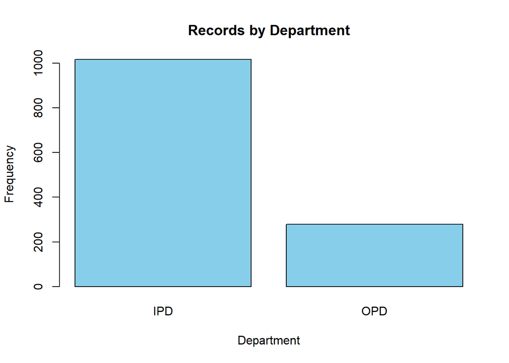

```r
barplot(table(dirdata$Department),
        main = "Records by Department",
        xlab = "Department",
        ylab = "Frequency",
        col = "skyblue")
```

## 10.2 Horizontal Bar Diagram

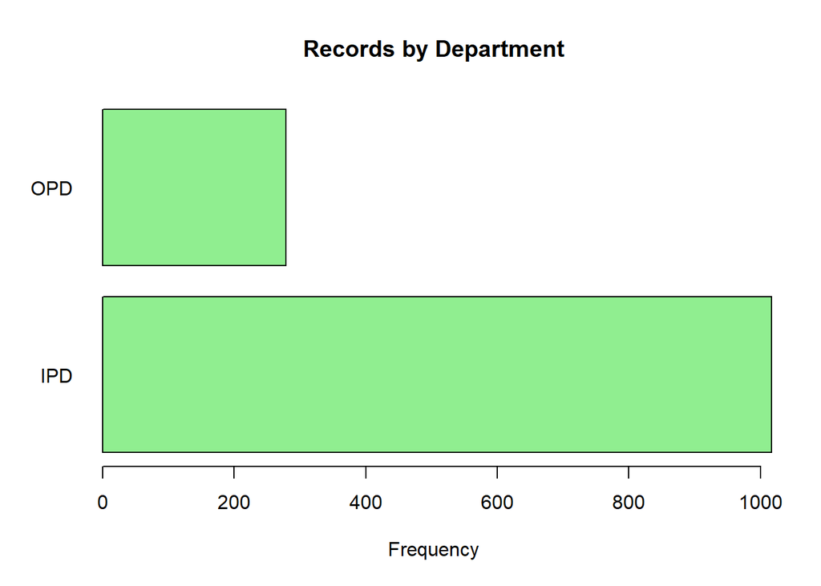

```r
barplot(table(dirdata$Department),
        horiz = TRUE,
        main = "Records by Department",
        xlab = "Frequency",
        col = "lightgreen",
        las = 1)
```

## 10.3 Percentage Bar Diagram

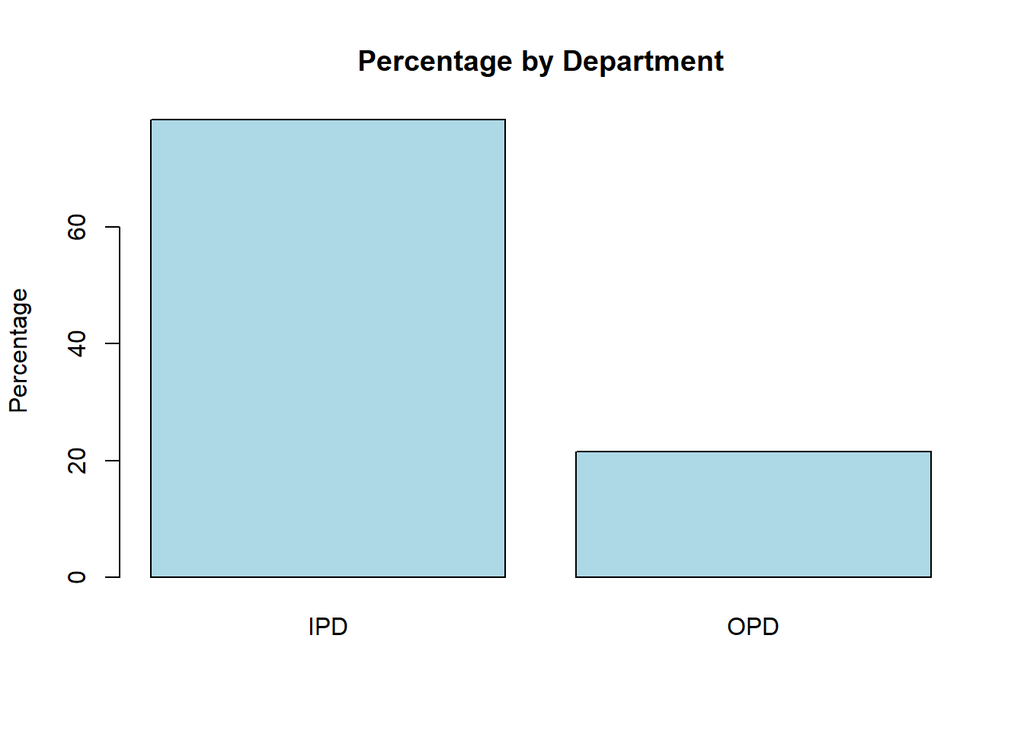

```r
dept <- prop.table(table(dirdata$Department)) * 100

barplot(dept,
        main = "Percentage by Department",
        ylab = "Percentage",
        col = "lightblue")
```

## 10.4 Grouped Bar Diagram

first we need a cross table

```r
table(dirdata$Department, dirdata$Sex)
```

```
##
##       Male Female
##   IPD  341    676
##   OPD   91    188
```

Bar diagram

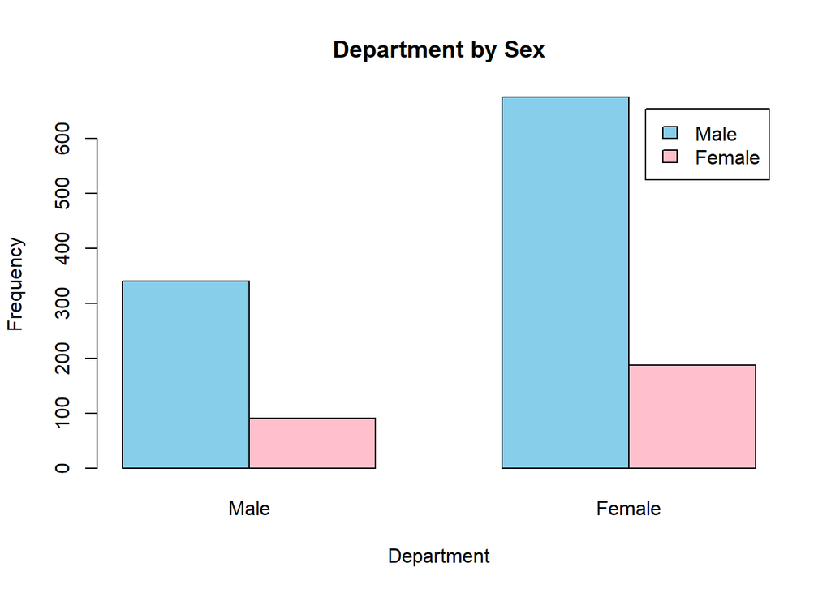

```r
tab <- table(dirdata$Department, dirdata$Sex)

barplot(tab,
        beside = TRUE,
        col = c("skyblue", "pink"),
        main = "Department by Sex",
        xlab = "Department",
        ylab = "Frequency",
        legend.text = colnames(tab))
```

## 10.5 Pie Diagram

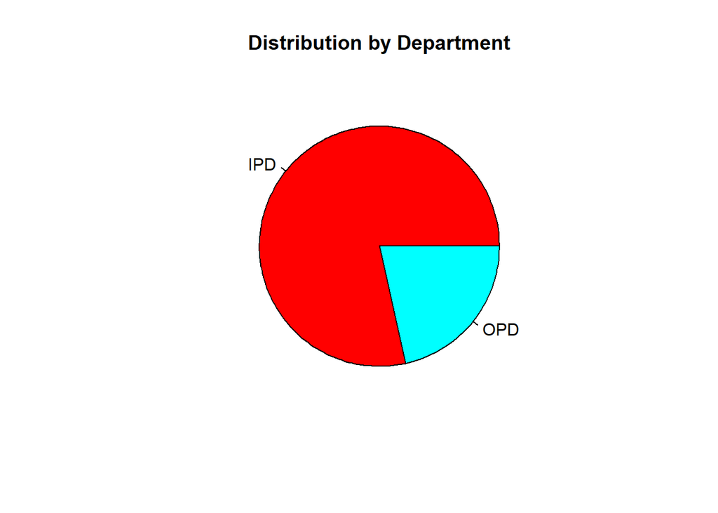

```r
pie(table(dirdata$Department),
    main = "Distribution by Department",
    col = rainbow(length(table(dirdata$Department))))
```

## 10.6 Pie Diagram with Percentage

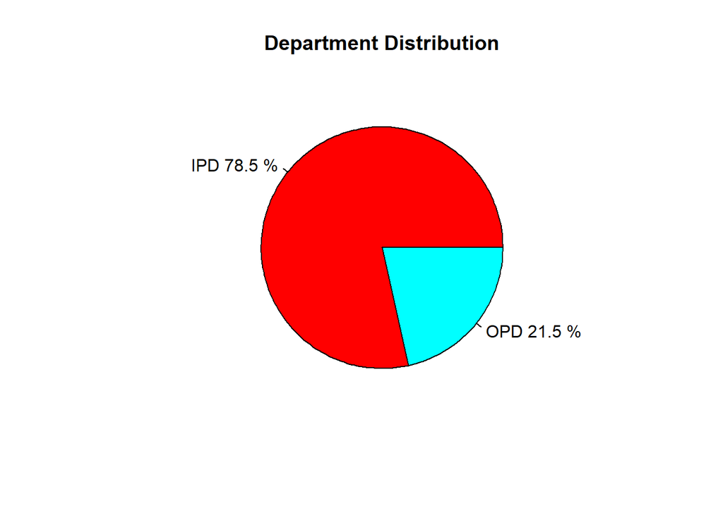

```r
dept <- table(dirdata$Department)

percent <- round(100 * dept / sum(dept), 1)

pie(dept,
    labels = paste(names(dept), percent, "%"),
    main = "Department Distribution",
    col = rainbow(length(dept)))
```

# 11 Visualizing of Numerical Variables

## 11.1 Scatter Diagram

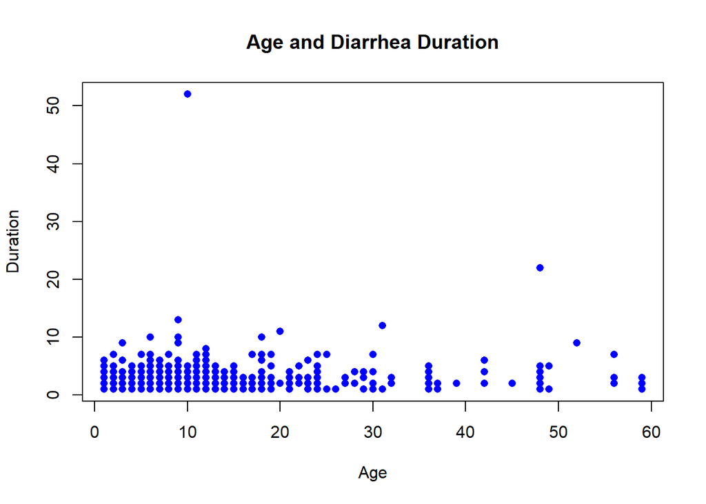

```r
plot(dirdata$Age,
     dirdata$DiaDurInDays,
     main = "Age and Diarrhea Duration",
     xlab = "Age",
     ylab = "Duration",
     pch = 16,
     col = "blue")
```

## 11.2 Scatter Diagram with Regression Line

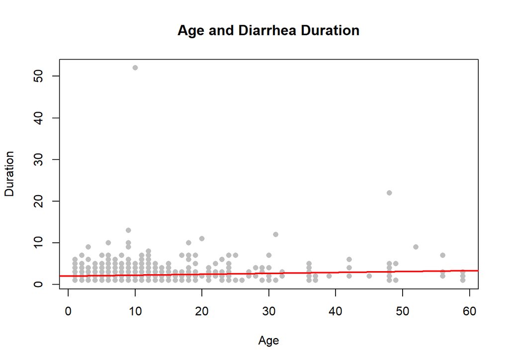

```r
plot(dirdata$Age,
     dirdata$DiaDurInDays,
     main = "Age and Diarrhea Duration",
     xlab = "Age",
     ylab = "Duration",
     pch = 16,
     col = "gray")

model <- lm(DiaDurInDays ~ Age, data = dirdata)

abline(model,
       col = "red",
       lwd = 2)
```

## 11.3 Histogram

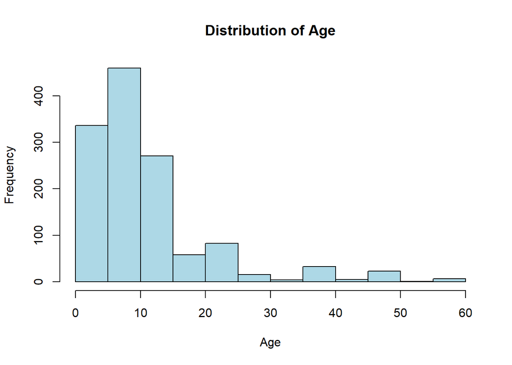

```r
hist(dirdata$Age,
     breaks = 20,
     main = "Distribution of Age",
     xlab = "Age",
     ylab = "Frequency",
     col = "lightblue")
```

## 11.4 Choosing the Number of Bins

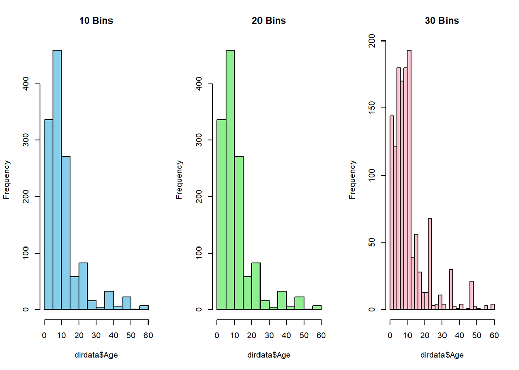

```r
par(mfrow = c(1, 3))

hist(dirdata$Age,
     breaks = 10,
     main = "10 Bins",
     col = "skyblue")

hist(dirdata$Age,
     breaks = 20,
     main = "20 Bins",
     col = "lightgreen")

hist(dirdata$Age,
     breaks = 30,
     main = "30 Bins",
     col = "pink")
```

```r
par(mfrow = c(1, 1))
```

## 11.5 Histogram with Mean and Median

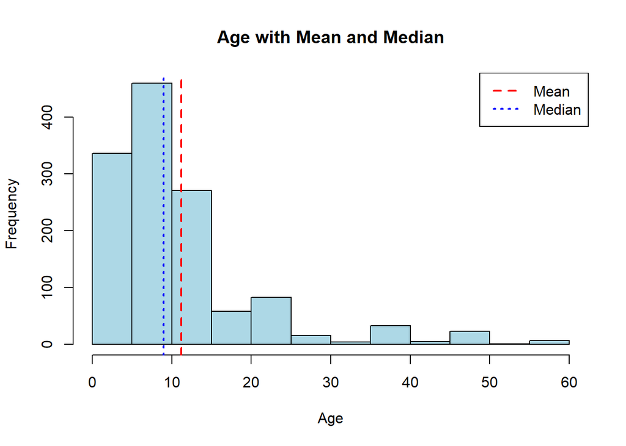

```r
hist(dirdata$Age,
     breaks = 20,
     col = "lightblue",
     main = "Age with Mean and Median",
     xlab = "Age")

abline(v = mean(dirdata$Age, na.rm = TRUE),
       col = "red",
       lwd = 2,
       lty = 2)

abline(v = median(dirdata$Age, na.rm = TRUE),
       col = "blue",
       lwd = 2,
       lty = 3)

legend("topright",
       legend = c("Mean", "Median"),
       col = c("red", "blue"),
       lty = c(2, 3),
       lwd = 2)
```

## 11.6 Boxplot

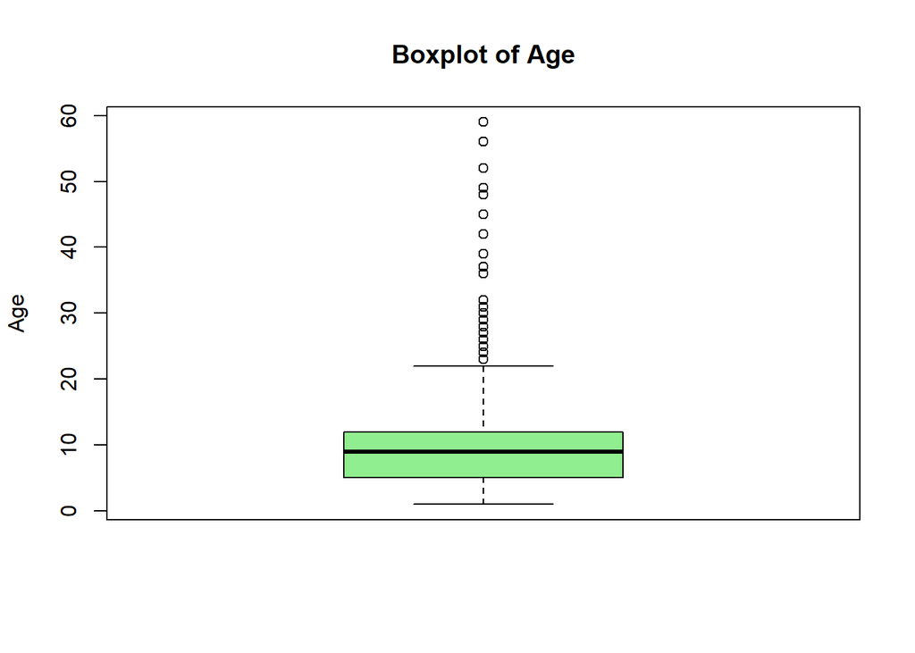

```r
boxplot(dirdata$Age,
        main = "Boxplot of Age",
        ylab = "Age",
        col = "lightgreen")
```

## 11.7 Boxplot by Department

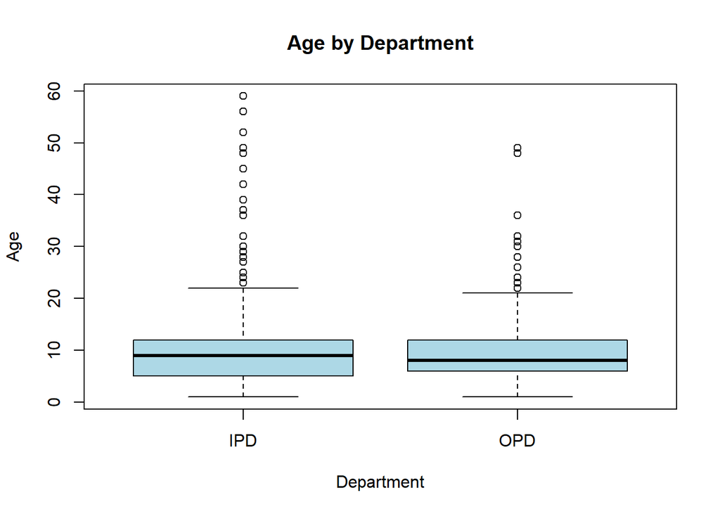

```r
boxplot(Age ~ Department,
        data = dirdata,
        main = "Age by Department",
        xlab = "Department",
        ylab = "Age",
        col = "lightblue")
```

## 11.8 Diarrhea Duration by Department

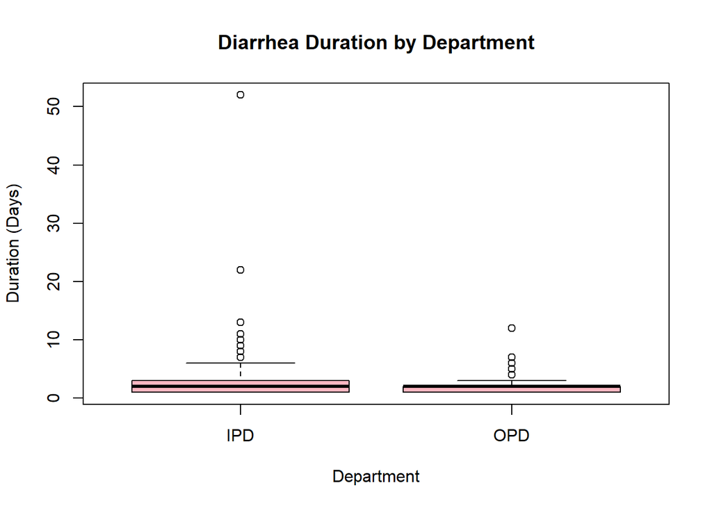

```r
boxplot(DiaDurInDays ~ Department,
        data = dirdata,
        main = "Diarrhea Duration by Department",
        xlab = "Department",
        ylab = "Duration (Days)",
        col = "lightpink")
```

## 11.9 Potential Outliers

```r
boxplot.stats(dirdata$Age)$out
```

```
##   [1] 37 23 23 32 24 48 24 48 27 24 49 24 24 48 24 36 32 24 28 24 24 59 48 36 24
##  [26] 24 48 24 48 36 24 48 24 48 24 24 36 31 25 28 56 24 42 39 36 24 24 24 24 24
##  [51] 36 48 23 24 36 23 26 36 25 36 36 48 36 45 24 24 24 24 24 24 24 48 48 24 48
##  [76] 24 24 24 48 24 56 48 24 36 48 48 36 36 24 24 24 24 24 36 24 24 36 24 36 27
## [101] 24 24 36 23 24 31 23 49 36 42 24 48 24 29 30 30 24 30 36 48 30 29 24 24 29
## [126] 24 24 56 59 24 37 59 48 36 36 36 23 29 36 48 36 30 24 42 36 42 52 24 30 30
## [151] 24 24 59 36 24 36 24 36 36
```

## 11.10 Density Plot

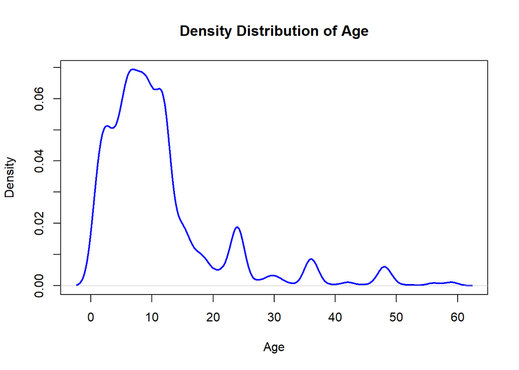

```r
plot(density(dirdata$Age, na.rm = TRUE),
     main = "Density Distribution of Age",
     xlab = "Age",
     ylab = "Density",
     col = "blue",
     lwd = 2)
```

## 11.11 Histogram with Density Curve

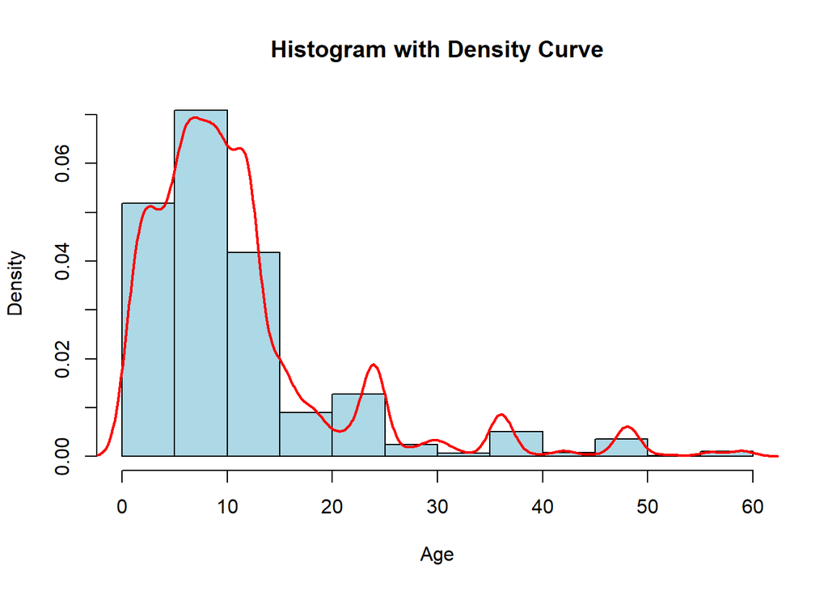

```r
hist(dirdata$Age,
     probability = TRUE,
     breaks = 20,
     col = "lightblue",
     main = "Histogram with Density Curve",
     xlab = "Age")

lines(density(dirdata$Age, na.rm = TRUE),
      col = "red",
      lwd = 2)
```

## 11.12 Line Diagram

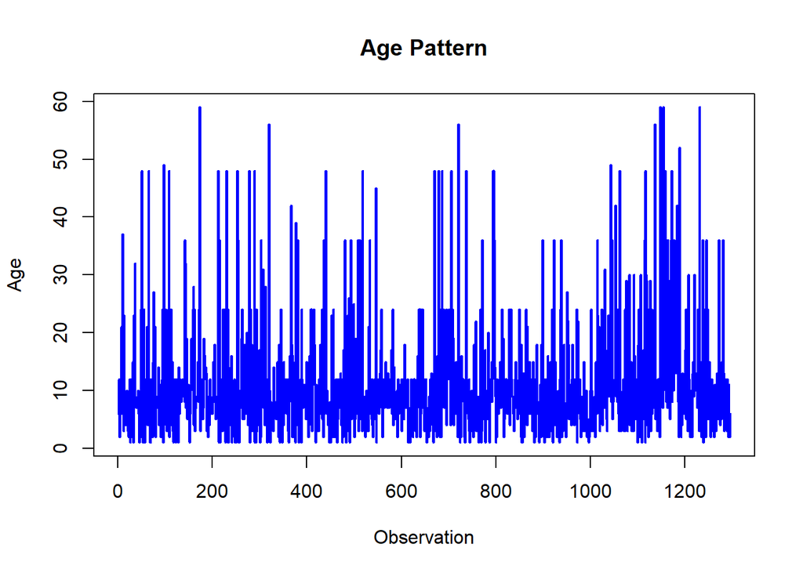

```r
plot(dirdata$Age,
     type = "l",
     main = "Age Pattern",
     xlab = "Observation",
     ylab = "Age",
     col = "blue",
     lwd = 2)
```

## 11.13 Line Diagram with Points

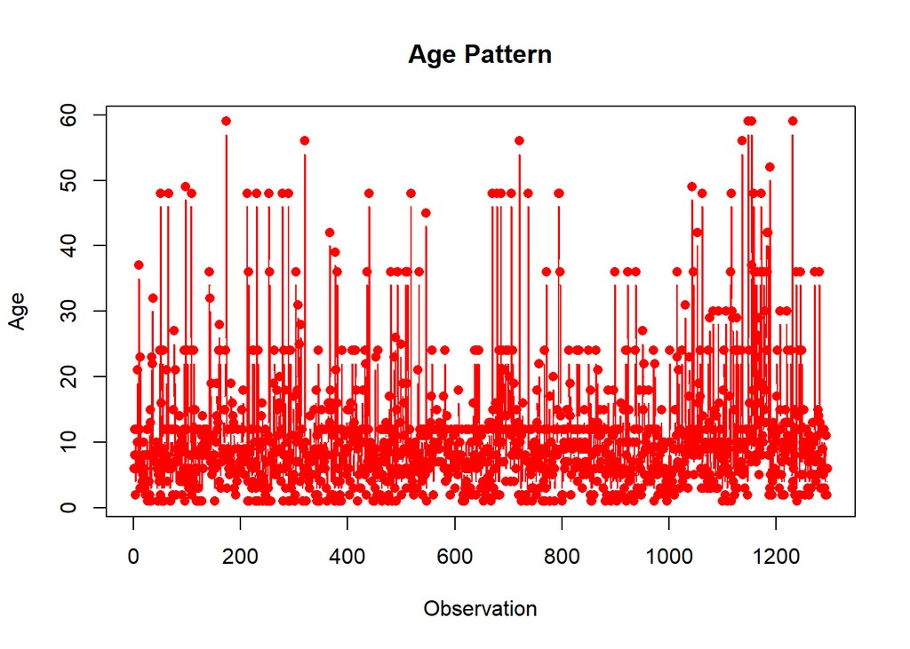

```r
plot(dirdata$Age,
     type = "b",
     main = "Age Pattern",
     xlab = "Observation",
     ylab = "Age",
     col = "red",
     pch = 16)
```

# 12 Correlation Analysis

## 12.1 Pearson Correlation

```r
cor(dirdata$Age,
    dirdata$DiaDurInDays,
    use = "complete.obs")
```

```
## [1] 0.1011935
```

## 12.2 Correlation Test

```r
cor.test(dirdata$Age,
         dirdata$DiaDurInDays,
         method = "pearson")
```

```
##
##  Pearson's product-moment correlation
##
## data:  dirdata$Age and dirdata$DiaDurInDays
## t = 3.6561, df = 1292, p-value = 0.0002664
## alternative hypothesis: true correlation is not equal to 0
## 95 percent confidence interval:
##  0.04695768 0.15483435
## sample estimates:
##       cor
## 0.1011935
```

## 12.3 Spearman Correlation

```r
cor.test(dirdata$Age,
         dirdata$DiaDurInDays,
         method = "spearman",
         use = "complete.obs")
```

```
##
##  Spearman's rank correlation rho
##
## data:  dirdata$Age and dirdata$DiaDurInDays
## S = 313095263, p-value = 1.582e-06
## alternative hypothesis: true rho is not equal to 0
## sample estimates:
##       rho
## 0.1329879
```

## 12.4 Correlation Matrix

```r
numeric_data <- dirdata[, c(
  "Age",
  "DiaMaxNo_24hrs",
  "DiaDurInDays"
)]

cor_matrix <- cor(numeric_data,
                  use = "pairwise.complete.obs")

cor_matrix
```

```
##                        Age DiaMaxNo_24hrs DiaDurInDays
## Age             1.00000000    -0.04324656   0.10119346
## DiaMaxNo_24hrs -0.04324656     1.00000000   0.06194965
## DiaDurInDays    0.10119346     0.06194965   1.00000000
```

## 12.5 Visualizing Correlation Matrix

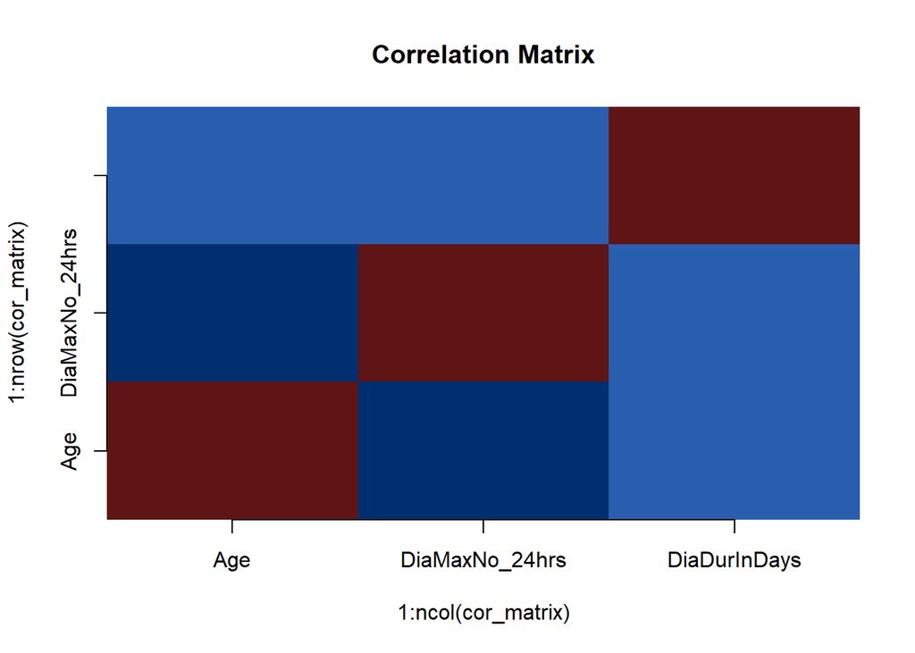

```r
image(1:ncol(cor_matrix),
      1:nrow(cor_matrix),
      cor_matrix,
      axes = FALSE,
      col = hcl.colors(20, "Blue-Red 3"),
      main = "Correlation Matrix")

axis(1,
     at = 1:ncol(cor_matrix),
     labels = colnames(cor_matrix))

axis(2,
     at = 1:nrow(cor_matrix),
     labels = rownames(cor_matrix))
```

# 13 Multiple Diagrams in One Window

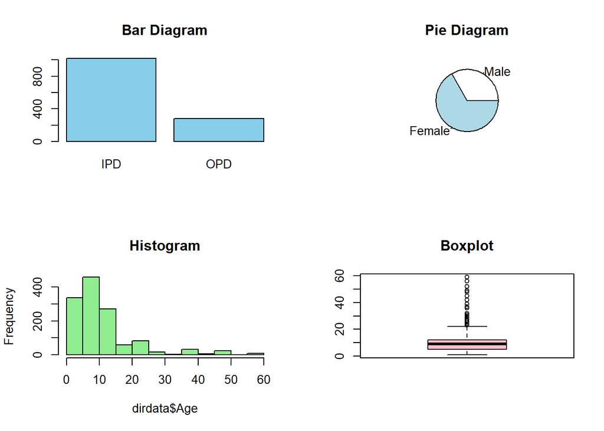

```r
par(mfrow = c(2, 2))

barplot(table(dirdata$Department),
        main = "Bar Diagram",
        col = "skyblue")

pie(table(dirdata$Sex),
    main = "Pie Diagram")

hist(dirdata$Age,
     main = "Histogram",
     col = "lightgreen")

boxplot(dirdata$Age,
        main = "Boxplot",
        col = "pink")
```

# 14 Diagrams using ggplot

ggplot is a function from the ggplot2 package in R used to create high-quality and attractive graphs and charts.

ggplot2 is one of the most widely used packages for data visualization in R.

The ggplot2 has not been designed in our course however the trainee can practice using this tutorials.

## 14.1 Histogram

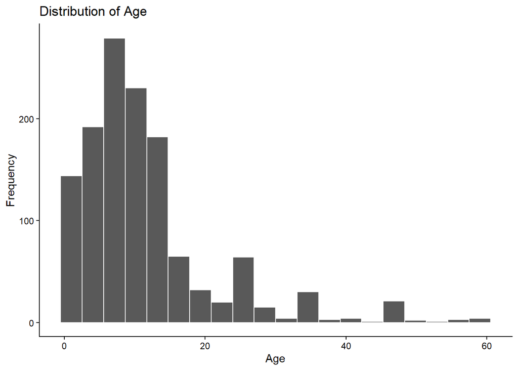

```r
ggplot(dirdata, aes(x = Age)) +
  geom_histogram(
    bins = 20,
    color = "white"
  ) +
  labs(
    title = "Distribution of Age",
    x = "Age",
    y = "Frequency"
  )
```

## 14.2 Choosing the number of bins

The number of bins affects the appearance of a histogram.

Try several values:

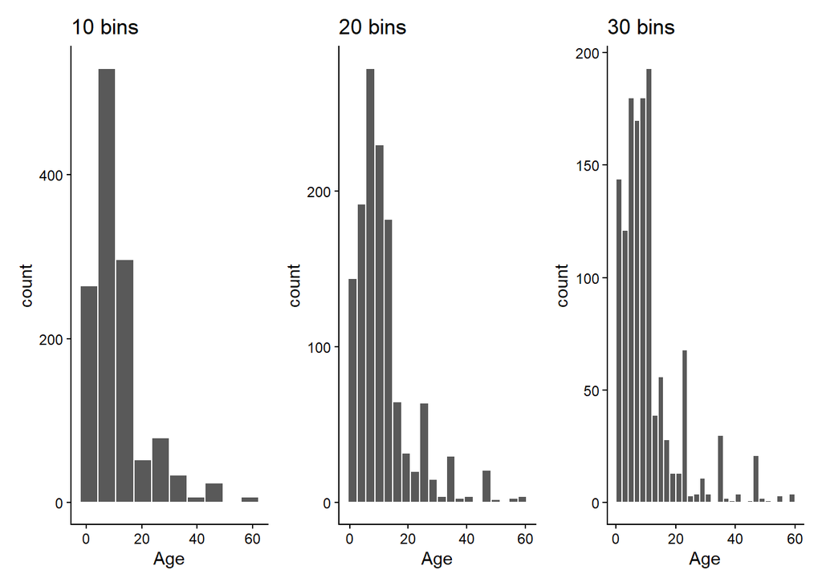

```r
p10 <- ggplot(dirdata, aes(x = Age)) +
  geom_histogram(bins = 10, color = "white") +
  labs(title = "10 bins")

p20 <- ggplot(dirdata, aes(x = Age)) +
  geom_histogram(bins = 20, color = "white") +
  labs(title = "20 bins")

p30 <- ggplot(dirdata, aes(x = Age)) +
  geom_histogram(bins = 30, color = "white") +
  labs(title = "30 bins")

p10 + p20 + p30
```

## 14.3 Density plot

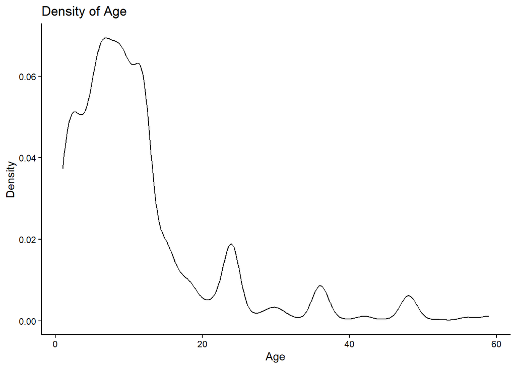

```r
ggplot(dirdata, aes(x = Age)) +
  geom_density(na.rm = TRUE) +
  labs(
    title = "Density of Age",
    x = "Age",
    y = "Density"
  )
```

## 14.4 Histogram with density

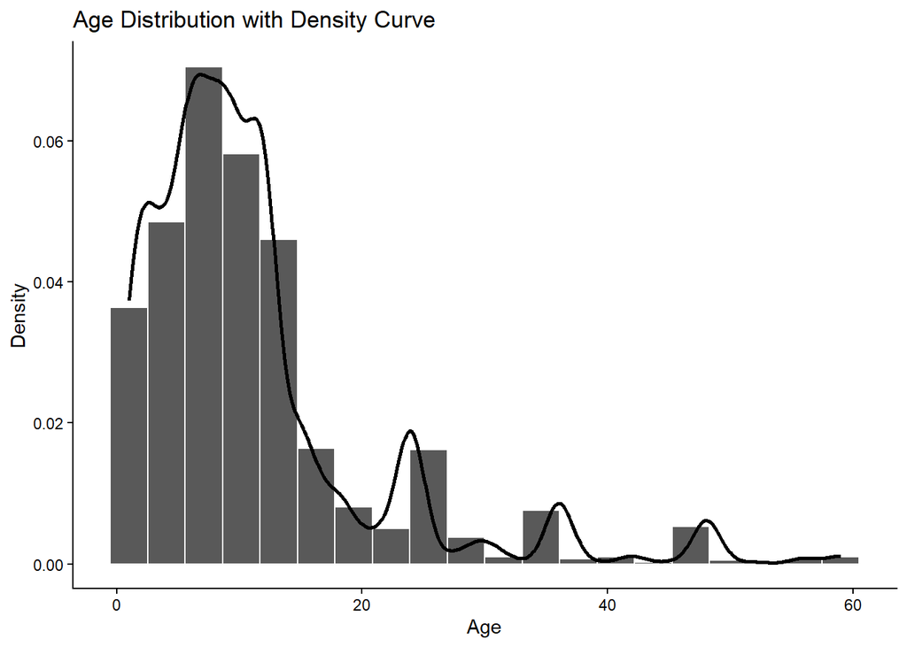

```r
ggplot(dirdata, aes(x = Age)) +
  geom_histogram(
    aes(y = after_stat(density)),
    bins = 20,
    color = "white"
  ) +
  geom_density(linewidth = 1) +
  labs(
    title = "Age Distribution with Density Curve",
    x = "Age",
    y = "Density"
  )
```

## 14.5 Mean and median

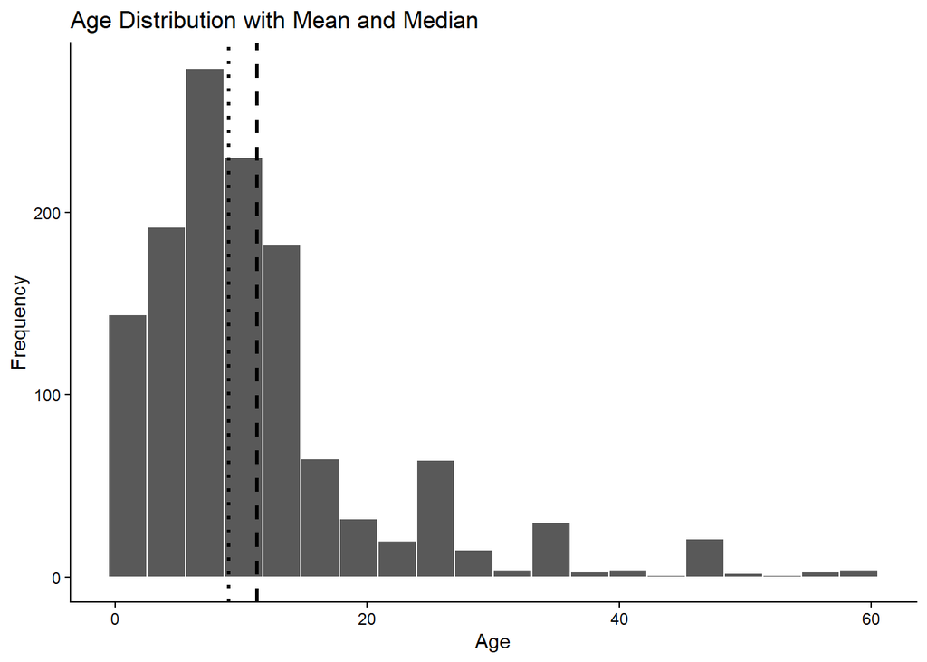

```r
age_mean <- mean(dirdata$Age, na.rm = TRUE)
age_median <- median(dirdata$Age, na.rm = TRUE)

ggplot(dirdata, aes(x = Age)) +
  geom_histogram(bins = 20, color = "white") +
  geom_vline(
    xintercept = age_mean,
    linetype = "dashed",
    linewidth = 1
  ) +
  geom_vline(
    xintercept = age_median,
    linetype = "dotted",
    linewidth = 1
  ) +
  labs(
    title = "Age Distribution with Mean and Median",
    x = "Age",
    y = "Frequency"
  )
```

# 15 Boxplots and Potential Outliers

## 15.1 Boxplot

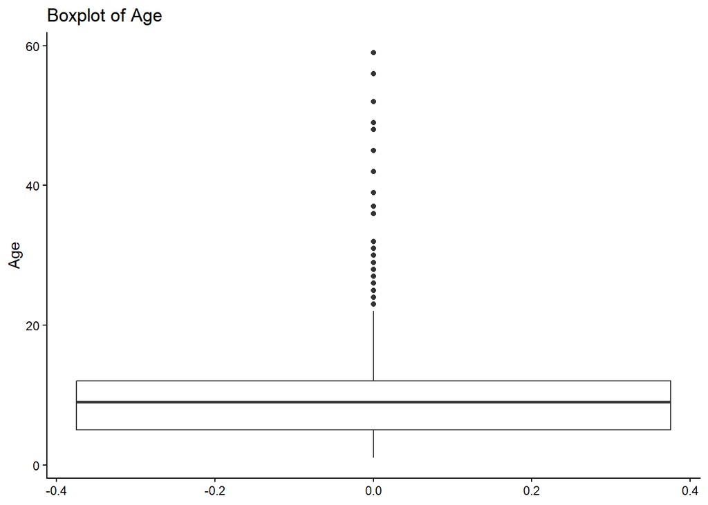

```r
ggplot(dirdata, aes(y = Age)) +
  geom_boxplot() +
  labs(
    title = "Boxplot of Age",
    y = "Age",
    x = NULL
  )
```

## 15.2 Boxplot statistics

```r
boxplot.stats(dirdata$Age)
```

```
## $stats
## [1]  1  5  9 12 22
##
## $n
## [1] 1296
##
## $conf
## [1] 8.692778 9.307222
##
## $out
##   [1] 37 23 23 32 24 48 24 48 27 24 49 24 24 48 24 36 32 24 28 24 24 59 48 36 24
##  [26] 24 48 24 48 36 24 48 24 48 24 24 36 31 25 28 56 24 42 39 36 24 24 24 24 24
##  [51] 36 48 23 24 36 23 26 36 25 36 36 48 36 45 24 24 24 24 24 24 24 48 48 24 48
##  [76] 24 24 24 48 24 56 48 24 36 48 48 36 36 24 24 24 24 24 36 24 24 36 24 36 27
## [101] 24 24 36 23 24 31 23 49 36 42 24 48 24 29 30 30 24 30 36 48 30 29 24 24 29
## [126] 24 24 56 59 24 37 59 48 36 36 36 23 29 36 48 36 30 24 42 36 42 52 24 30 30
## [151] 24 24 59 36 24 36 24 36 36
```

## 15.3 Potential outliers

```r
boxplot.stats(dirdata$Age)$out
```

```
##   [1] 37 23 23 32 24 48 24 48 27 24 49 24 24 48 24 36 32 24 28 24 24 59 48 36 24
##  [26] 24 48 24 48 36 24 48 24 48 24 24 36 31 25 28 56 24 42 39 36 24 24 24 24 24
##  [51] 36 48 23 24 36 23 26 36 25 36 36 48 36 45 24 24 24 24 24 24 24 48 48 24 48
##  [76] 24 24 24 48 24 56 48 24 36 48 48 36 36 24 24 24 24 24 36 24 24 36 24 36 27
## [101] 24 24 36 23 24 31 23 49 36 42 24 48 24 29 30 30 24 30 36 48 30 29 24 24 29
## [126] 24 24 56 59 24 37 59 48 36 36 36 23 29 36 48 36 30 24 42 36 42 52 24 30 30
## [151] 24 24 59 36 24 36 24 36 36
```

> A boxplot outlier is an observation identified by a statistical rule. It is **not automatically an error**. Check the original record before deciding whether an observation should be corrected, retained, or excluded.

# 16 Comparing Groups

## 16.1 Age by Department

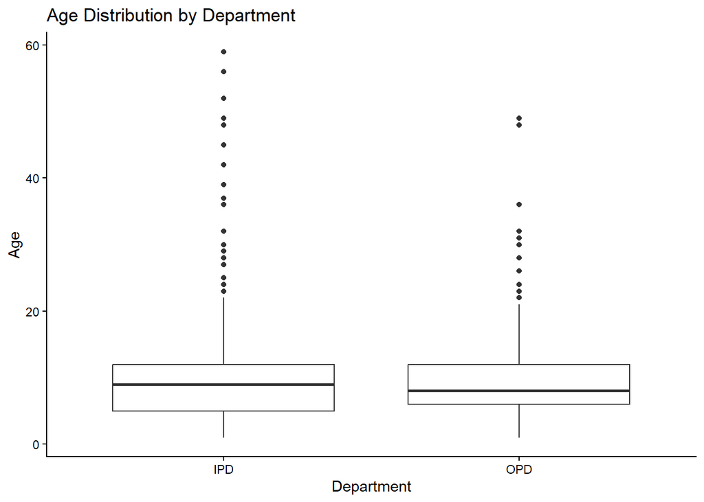

```r
ggplot(dirdata, aes(x = Department, y = Age)) +
  geom_boxplot() +
  labs(
    title = "Age Distribution by Department",
    x = "Department",
    y = "Age"
  )
```

## 16.2 Add individual observations

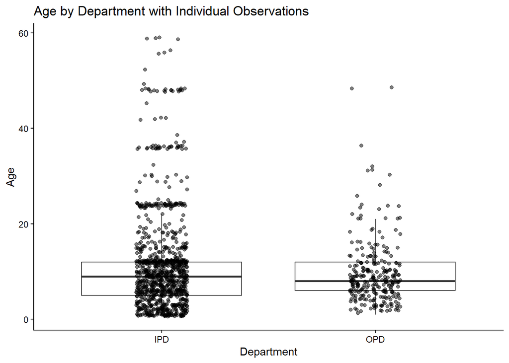

```r
ggplot(dirdata, aes(x = Department, y = Age)) +
  geom_boxplot(outlier.shape = NA) +
  geom_jitter(
    width = 0.12,
    alpha = 0.5
  ) +
  labs(
    title = "Age by Department with Individual Observations",
    x = "Department",
    y = "Age"
  )
```

## 16.3 Distribution of diarrhea duration by Department

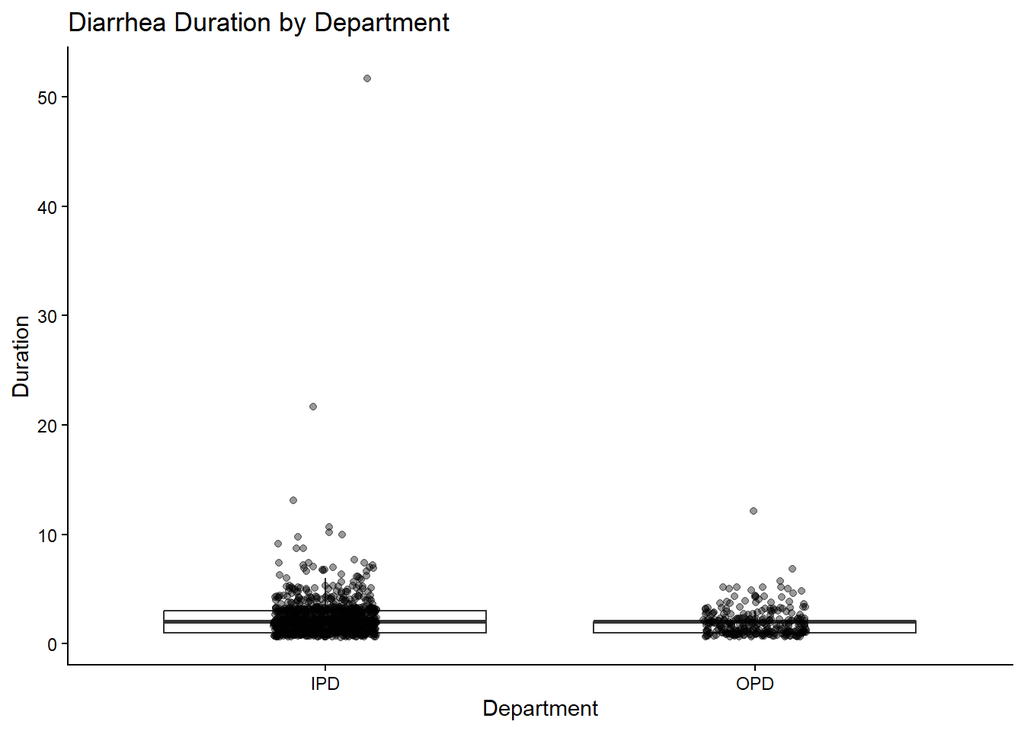

```r
ggplot(dirdata, aes(x = Department, y = DiaDurInDays)) +
  geom_boxplot(outlier.shape = NA) +
  geom_jitter(width = 0.12, alpha = 0.4) +
  labs(
    title = "Diarrhea Duration by Department",
    x = "Department",
    y = "Duration"
  )
```

## 16.4 Dehydration by Department

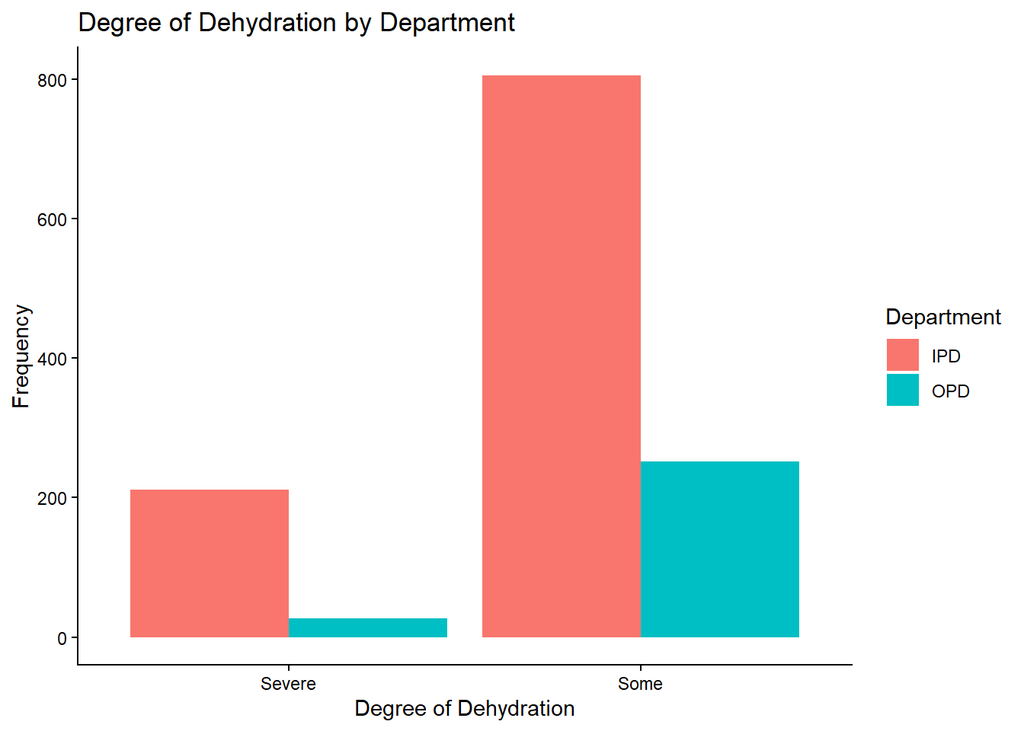

```r
ggplot(dirdata, aes(x = DegreeDehy, fill = Department)) +
  geom_bar(position = "dodge") +
  labs(
    title = "Degree of Dehydration by Department",
    x = "Degree of Dehydration",
    y = "Frequency",
    fill = "Department"
  )
```

# 17 Bar Charts for Categorical Variables

## 17.1 Basic bar chart

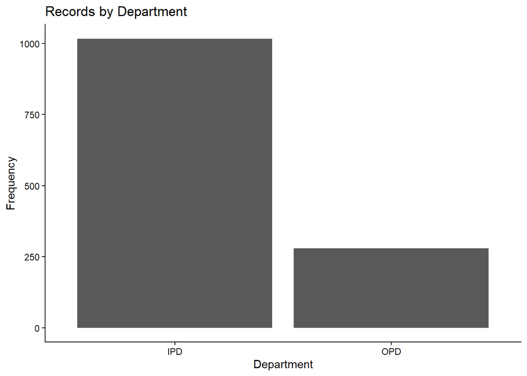

```r
ggplot(dirdata, aes(x = Department)) +
  geom_bar() +
  labs(
    title = "Records by Department",
    x = "Department",
    y = "Frequency"
  )
```

## 17.2 Horizontal bar chart

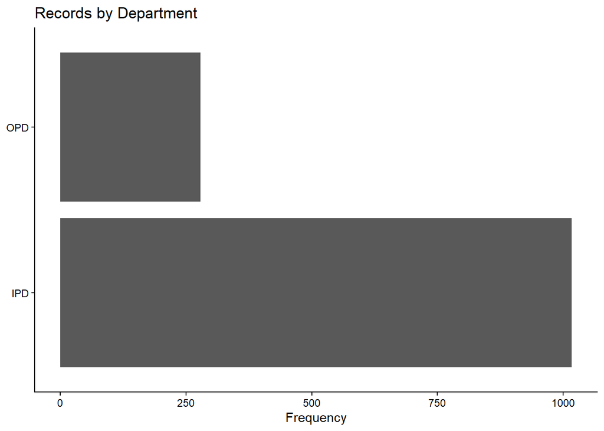

```r
ggplot(dirdata, aes(x = Department)) +
  geom_bar() +
  coord_flip() +
  labs(
    title = "Records by Department",
    x = NULL,
    y = "Frequency"
  )
```